Mark Attwood  
28-APR-2024

# Multilayer Perceptron Models with the Kaggle Heart Disease Dataset

https://www.kaggle.com/datasets/mexwell/heart-disease-dataset

```python
import numpy as np
import pandas as pd
import matplotlib.pyplot as plt
import seaborn as sns

import multiprocessing
import copy

import shap

from tensorflow.keras.models import Sequential
from tensorflow.keras.layers import Dense
from tensorflow.keras.callbacks import EarlyStopping, ModelCheckpoint
from tensorflow.keras.metrics import F1Score, Recall, AUC

import statsmodels.formula.api as smf

from sklearn.metrics import accuracy_score, precision_score, recall_score, f1_score, confusion_matrix
from sklearn.metrics import ConfusionMatrixDisplay
```

```python
def scores(_y_val, _y_pred):
    tn, fp, fn, tp = confusion_matrix(_y_val, _y_pred).ravel()
    specificity = tn / (tn+fp)
    print("Accuracy: ", round(accuracy_score(_y_val, _y_pred), 2))
    print("Specificity: ", round(tn / (tn+fp), 2))
    print("Recall: ", round(recall_score(_y_val, _y_pred), 2))
    print("F1 Score:", round(f1_score(_y_val, _y_pred), 2))
```

```python
callback_a = ModelCheckpoint(filepath = 'my_best_model.hdf5', monitor='val_loss', save_best_only = True, save_weights_only = True, verbose = 0)
callback_b = EarlyStopping(monitor='val_loss', mode='min', patience=50, verbose=1)
```

```python
def train_model(model, X, y, X_test, y_test, callback=[callback_a, callback_b]):
	model.compile(loss='binary_crossentropy', optimizer='adam', metrics=['Recall', 'accuracy', 'AUC'])
	return model.fit(X, y, validation_data=(X_test, y_test), epochs=1000, callbacks=callback, verbose=0)
```

```python
def evaluate_model(model, history, X, y):
    y_pred_k = model.predict(X)
    y_pred_kb = (y_pred_k >= 0.5)*1

    scores(y, y_pred_kb)

    pd.DataFrame(history.history).iloc[:, [2,4,5,6,7]].plot(figsize=(8,5))
    plt.ylim(-0.05,1.05)
    plt.show()


    # x = np.arange(0,1.01,.01)
    # recall = [recall_score(y, (y_pred_k >= i)*1) for i in x]
    # accuracy = [accuracy_score(y, (y_pred_k >= i)*1) for i in x]
    # sns.scatterplot(x=x, y=recall, label="recall", s=20)
    # sns.scatterplot(x=x, y=accuracy, label="accuracy", s=20)
    # plt.title("Recall and Accuracy Againt Probability Cut-Off")
    # plt.ylabel("Recall or Accuracy")
    # plt.xlabel("Cut-Off Value")
    # plt.legend()
    # plt.show()


    conf_matrix = confusion_matrix(y_true=y, y_pred=y_pred_kb)
    vis = ConfusionMatrixDisplay(confusion_matrix=conf_matrix)
    vis.plot()
    plt.show()
```

```python
def one_hot_encode(data, col_name, drop_first=True):
    values = sorted(list(data.unique()))
    df_oh = pd.DataFrame()
    for value in values:
        df_oh[col_name+"_"+str(value)] = np.where(data == value, 1, 0)
    if drop_first:
        return df_oh.iloc[:, 1:]
    else:
        return df_oh
```

## Phase 1: Data Analysis and Preparation

- Once you have found a dataset you like
- load the data in a Python Notebook
- normalize your data. CANNOT DO THIS UNTIL DATA IS SPLIT.
- In your report’s introduction section please discuss:
  - why you chose to work on this project
  - explain the problem you plan to solve.
  - mention the source of your dataset.
- visualize/plot the distributions of each input feature and discuss the range of the values (min, max, mean, median, etc.). For example, plot histograms showing distribution of each input features. Selected visualizations should be included in the report.
- Discuss the distribution of the output labels.
- Check if the data is imbalanced by calculating what percentage of the output labels are 0 and what percentage are 1. If your dataset is heavily imbalanced (for example, 1% vs 99%) it may be a better idea to choose a different dataset.

```python
df = pd.read_csv("heart.csv")
```

```python
df.info()
```

```
<class 'pandas.core.frame.DataFrame'>
RangeIndex: 1190 entries, 0 to 1189
Data columns (total 12 columns):
 #   Column               Non-Null Count  Dtype
---  ------               --------------  -----
 0   age                  1190 non-null   int64
 1   sex                  1190 non-null   int64
 2   chest pain type      1190 non-null   int64
 3   resting bp s         1190 non-null   int64
 4   cholesterol          1190 non-null   int64
 5   fasting blood sugar  1190 non-null   int64
 6   resting ecg          1190 non-null   int64
 7   max heart rate       1190 non-null   int64
 8   exercise angina      1190 non-null   int64
 9   oldpeak              1190 non-null   float64
 10  ST slope             1190 non-null   int64
 11  target               1190 non-null   int64
dtypes: float64(1), int64(11)
memory usage: 111.7 KB
```

```python
df.head(3)
```

|  | age | sex | chest pain type | resting bp s | cholesterol | fasting blood sugar | resting ecg | max heart rate | exercise angina | oldpeak | ST slope | target |
| --- | --- | --- | --- | --- | --- | --- | --- | --- | --- | --- | --- | --- |
| 0 | 40 | 1 | 2 | 140 | 289 | 0 | 0 | 172 | 0 | 0.0 | 1 | 0 |
| 1 | 49 | 0 | 3 | 160 | 180 | 0 | 0 | 156 | 0 | 1.0 | 2 | 1 |
| 2 | 37 | 1 | 2 | 130 | 283 | 0 | 1 | 98 | 0 | 0.0 | 1 | 0 |

```python
df.describe().transpose()
```

|  | count | mean | std | min | 25% | 50% | 75% | max |
| --- | --- | --- | --- | --- | --- | --- | --- | --- |
| age | 1190.0 | 53.720168 | 9.358203 | 28.0 | 47.0 | 54.0 | 60.00 | 77.0 |
| sex | 1190.0 | 0.763866 | 0.424884 | 0.0 | 1.0 | 1.0 | 1.00 | 1.0 |
| chest pain type | 1190.0 | 3.232773 | 0.935480 | 1.0 | 3.0 | 4.0 | 4.00 | 4.0 |
| resting bp s | 1190.0 | 132.153782 | 18.368823 | 0.0 | 120.0 | 130.0 | 140.00 | 200.0 |
| cholesterol | 1190.0 | 210.363866 | 101.420489 | 0.0 | 188.0 | 229.0 | 269.75 | 603.0 |
| fasting blood sugar | 1190.0 | 0.213445 | 0.409912 | 0.0 | 0.0 | 0.0 | 0.00 | 1.0 |
| resting ecg | 1190.0 | 0.698319 | 0.870359 | 0.0 | 0.0 | 0.0 | 2.00 | 2.0 |
| max heart rate | 1190.0 | 139.732773 | 25.517636 | 60.0 | 121.0 | 140.5 | 160.00 | 202.0 |
| exercise angina | 1190.0 | 0.387395 | 0.487360 | 0.0 | 0.0 | 0.0 | 1.00 | 1.0 |
| oldpeak | 1190.0 | 0.922773 | 1.086337 | -2.6 | 0.0 | 0.6 | 1.60 | 6.2 |
| ST slope | 1190.0 | 1.624370 | 0.610459 | 0.0 | 1.0 | 2.0 | 2.00 | 3.0 |
| target | 1190.0 | 0.528571 | 0.499393 | 0.0 | 0.0 | 1.0 | 1.00 | 1.0 |

```python
df.target.value_counts(normalize=True).round(2)
```

```
target
1    0.53
0    0.47
Name: proportion, dtype: float64
```

```python
cat_cols = ["chest pain type", "resting ecg", "ST slope"]
cat_prefs = ["chest_pain_type", "ecg", "ST_slope"]
numeric_cols = ["age", "resting_bp_s", "cholesterol", "max_heart_rate", "oldpeak"]
```

```python
for col, name in zip(cat_cols, cat_prefs):
    df_temp = one_hot_encode(df[col], name)
    df.drop(labels=col, axis=1, inplace=True)
    df = pd.concat([df, df_temp], axis=1)
```

```python
df.describe().transpose()
```

|  | count | mean | std | min | 25% | 50% | 75% | max |
| --- | --- | --- | --- | --- | --- | --- | --- | --- |
| age | 1190.0 | 53.720168 | 9.358203 | 28.0 | 47.0 | 54.0 | 60.00 | 77.0 |
| sex | 1190.0 | 0.763866 | 0.424884 | 0.0 | 1.0 | 1.0 | 1.00 | 1.0 |
| resting bp s | 1190.0 | 132.153782 | 18.368823 | 0.0 | 120.0 | 130.0 | 140.00 | 200.0 |
| cholesterol | 1190.0 | 210.363866 | 101.420489 | 0.0 | 188.0 | 229.0 | 269.75 | 603.0 |
| fasting blood sugar | 1190.0 | 0.213445 | 0.409912 | 0.0 | 0.0 | 0.0 | 0.00 | 1.0 |
| max heart rate | 1190.0 | 139.732773 | 25.517636 | 60.0 | 121.0 | 140.5 | 160.00 | 202.0 |
| exercise angina | 1190.0 | 0.387395 | 0.487360 | 0.0 | 0.0 | 0.0 | 1.00 | 1.0 |
| oldpeak | 1190.0 | 0.922773 | 1.086337 | -2.6 | 0.0 | 0.6 | 1.60 | 6.2 |
| target | 1190.0 | 0.528571 | 0.499393 | 0.0 | 0.0 | 1.0 | 1.00 | 1.0 |
| chest_pain_type_2 | 1190.0 | 0.181513 | 0.385604 | 0.0 | 0.0 | 0.0 | 0.00 | 1.0 |
| chest_pain_type_3 | 1190.0 | 0.237815 | 0.425924 | 0.0 | 0.0 | 0.0 | 0.00 | 1.0 |
| chest_pain_type_4 | 1190.0 | 0.525210 | 0.499574 | 0.0 | 0.0 | 1.0 | 1.00 | 1.0 |
| ecg_1 | 1190.0 | 0.152101 | 0.359270 | 0.0 | 0.0 | 0.0 | 0.00 | 1.0 |
| ecg_2 | 1190.0 | 0.273109 | 0.445744 | 0.0 | 0.0 | 0.0 | 1.00 | 1.0 |
| ST_slope_1 | 1190.0 | 0.442017 | 0.496835 | 0.0 | 0.0 | 0.0 | 1.00 | 1.0 |
| ST_slope_2 | 1190.0 | 0.489076 | 0.500091 | 0.0 | 0.0 | 0.0 | 1.00 | 1.0 |
| ST_slope_3 | 1190.0 | 0.068067 | 0.251967 | 0.0 | 0.0 | 0.0 | 0.00 | 1.0 |

```python
# Remove white space from feature names
for col in df.columns:
    df.rename({col: col.replace(" ", "_")}, axis=1, inplace=True)
```

```python
cat_cols_d = ['sex', 'fasting_blood_sugar',
       'exercise_angina', 'target',
       'chest_pain_type_2', 'chest_pain_type_3', 'chest_pain_type_4', 'ecg_1',
       'ecg_2', 'ST_slope_1', 'ST_slope_2', 'ST_slope_3']
```

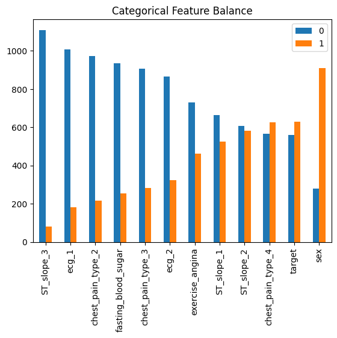

```python
df.loc[:,cat_cols_d].apply(pd.Series.value_counts).transpose().dropna().astype(int).sort_values(by=1.0).plot(kind='bar')
plt.title("Categorical Feature Balance")
plt.show()
```

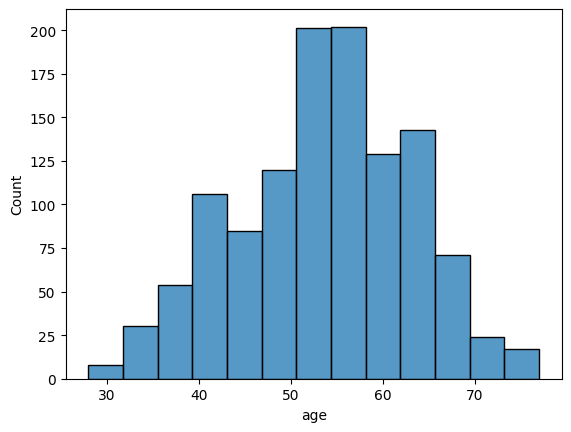

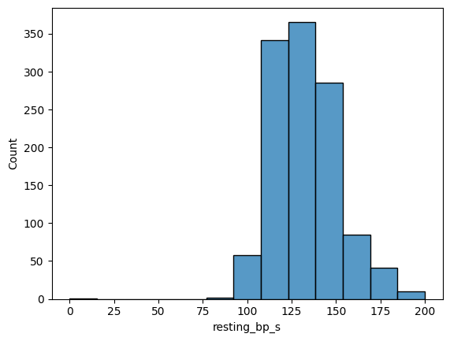

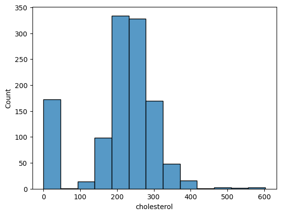

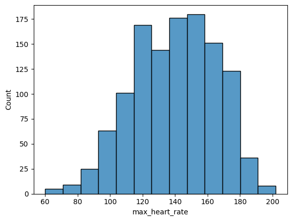

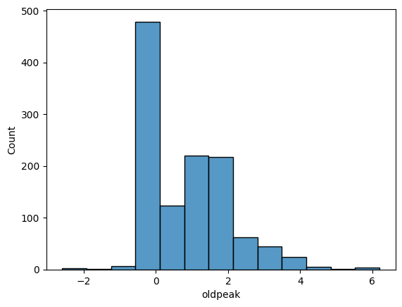

```python
for column in numeric_cols:
    sns.histplot(data = df, x=column, bins=13)
    plt.show()
```

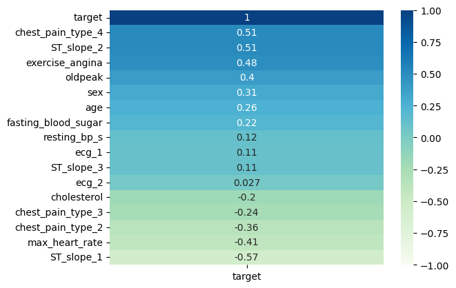

```python
# Plotting the heatmap to check the correlation between the Target Label and other features
sns.heatmap(df.corr()[['target']].sort_values(by='target', ascending=False), vmin=-1, vmax=1, annot=True, cmap='GnBu')
plt.show()
```

## Phase 2: Build a Model to Overfit the Entire Dataset

The main goal in this phase is to experiment and find what network size is needed to ‘overfit’ the entire dataset at your hand.

- Do not split your data into training and validation.
- The place to start is to use ‘logistic regression’ model and train for as many epochs as needed to obtain as high accuracy as possible.

After training hundreds of epochs if you observe that the accuracy is not increasing then it implies that the number of neurons in your model (only one) may not be sufficient for overfitting.

- The next step is to grow your model into a multi-layer model and add a few neurons (say only 2) in the input layer. This way your model will have ‘2 + 1 = 3’ neurons in total.
- If your accuracy still does not each a 100% or close to 100% you can continue to increase the number of layers and number of neurons.
- Once you have obtained 100% accuracy (or around 100%) your experiments for this phase are complete.

The results of this experiment also inform us that our final model (in subsequent phases) should be smaller than this model.

### Standardize Numeric Data and Prepare for Use in ML Models

```python
def data_norms(data):
    mean_ = data.mean()
    std_ = data.std()
    return (data - mean_)/std_
```

```python
np.random.seed(2112)
df_2 = df.copy().sample(frac=1)
```

```python
for column in numeric_cols:
    df_2[column] = data_norms(df_2[column])
```

```python
df_2[numeric_cols].describe().transpose()
```

|  | count | mean | std | min | 25% | 50% | 75% | max |
| --- | --- | --- | --- | --- | --- | --- | --- | --- |
| age | 1190.0 | -3.015328e-16 | 1.0 | -2.748409 | -0.718105 | 0.029902 | 0.671051 | 2.487639 |
| resting_bp_s | 1190.0 | 3.119820e-16 | 1.0 | -7.194461 | -0.661653 | -0.117252 | 0.427149 | 3.693553 |
| cholesterol | 1190.0 | 9.852063e-17 | 1.0 | -2.074175 | -0.220506 | 0.183751 | 0.585544 | 3.871369 |
| max_heart_rate | 1190.0 | -4.522993e-16 | 1.0 | -3.124614 | -0.734111 | 0.030067 | 0.794244 | 2.440164 |
| oldpeak | 1190.0 | 1.000134e-16 | 1.0 | -3.242799 | -0.849435 | -0.297121 | 0.623404 | 4.857817 |

```python
X = df_2.drop(axis=1, labels='target')
y = df_2['target']
```

### Build increasingly more complex models

```python
model = Sequential()
model.add(Dense(1, input_dim=X.shape[1], activation='sigmoid'))
print(model.summary())
history = train_model(model, X, y, X, y)
```

```
Model: "sequential"
_________________________________________________________________
 Layer (type)                Output Shape              Param #
=================================================================
 dense (Dense)               (None, 1)                 17

=================================================================
Total params: 17 (68.00 Byte)
Trainable params: 17 (68.00 Byte)
Non-trainable params: 0 (0.00 Byte)
_________________________________________________________________
None
```

```
Accuracy:  0.85
Specificity:  0.83
Recall:  0.88
F1 Score: 0.86
```

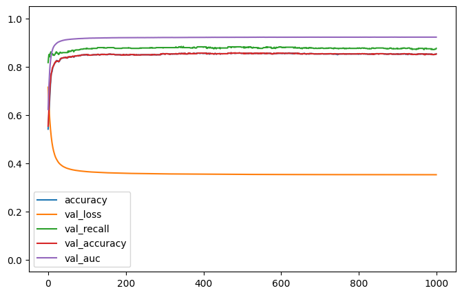

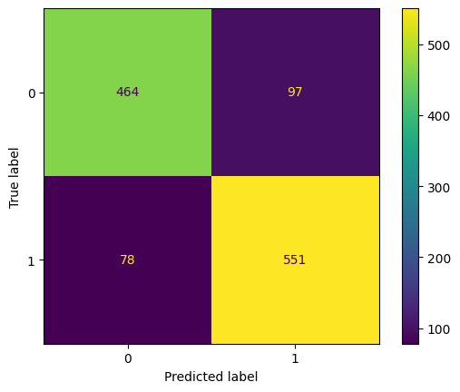

```python
evaluate_model(model, history, X, y)
```

```python
model = Sequential()
model.add(Dense(2, input_dim=X.shape[1], activation='relu'))
model.add(Dense(1, activation='sigmoid'))
print(model.summary())
history = train_model(model, X, y, X, y)
```

```
Model: "sequential_1"
_________________________________________________________________
 Layer (type)                Output Shape              Param #
=================================================================
 dense_1 (Dense)             (None, 2)                 34

 dense_2 (Dense)             (None, 1)                 3

=================================================================
Total params: 37 (148.00 Byte)
Trainable params: 37 (148.00 Byte)
Non-trainable params: 0 (0.00 Byte)
_________________________________________________________________
None
```

```
Accuracy:  0.86
Specificity:  0.85
Recall:  0.88
F1 Score: 0.87
```

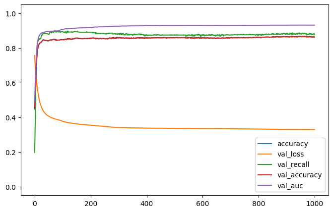

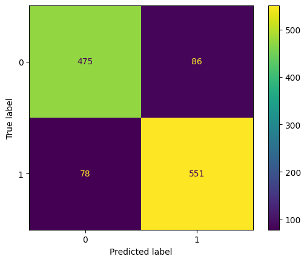

```python
evaluate_model(model, history, X, y)
```

```python
model = Sequential()
model.add(Dense(4, input_dim=X.shape[1], activation='relu'))
model.add(Dense(1, activation='sigmoid'))
print(model.summary())
history = train_model(model, X, y, X, y)
```

```
Model: "sequential_2"
_________________________________________________________________
 Layer (type)                Output Shape              Param #
=================================================================
 dense_3 (Dense)             (None, 4)                 68

 dense_4 (Dense)             (None, 1)                 5

=================================================================
Total params: 73 (292.00 Byte)
Trainable params: 73 (292.00 Byte)
Non-trainable params: 0 (0.00 Byte)
_________________________________________________________________
None
```

```
Accuracy:  0.88
Specificity:  0.86
Recall:  0.9
F1 Score: 0.89
```

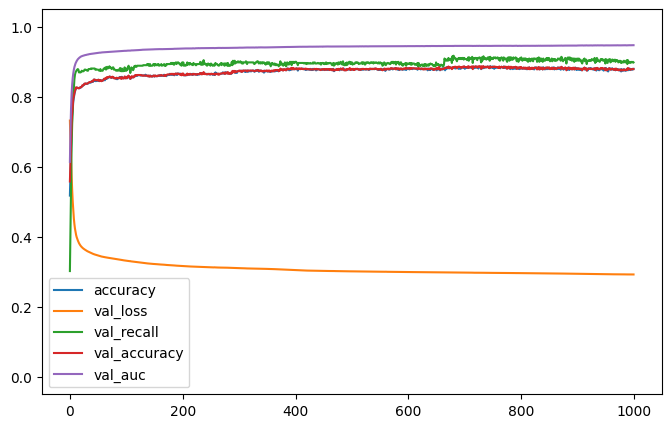

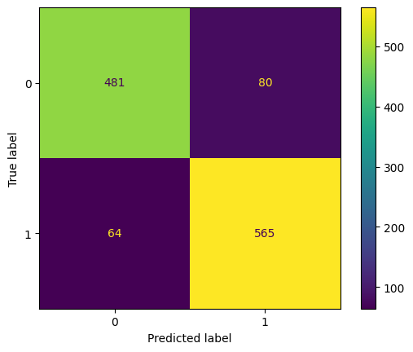

```python
evaluate_model(model, history, X, y)
```

```python
model = Sequential()
model.add(Dense(8, input_dim=X.shape[1], activation='relu'))
model.add(Dense(1, activation='sigmoid'))
print(model.summary())
history = train_model(model, X, y, X, y)
```

```
Model: "sequential_3"
_________________________________________________________________
 Layer (type)                Output Shape              Param #
=================================================================
 dense_5 (Dense)             (None, 8)                 136

 dense_6 (Dense)             (None, 1)                 9

=================================================================
Total params: 145 (580.00 Byte)
Trainable params: 145 (580.00 Byte)
Non-trainable params: 0 (0.00 Byte)
_________________________________________________________________
None
```

```
Accuracy:  0.91
Specificity:  0.89
Recall:  0.93
F1 Score: 0.91
```

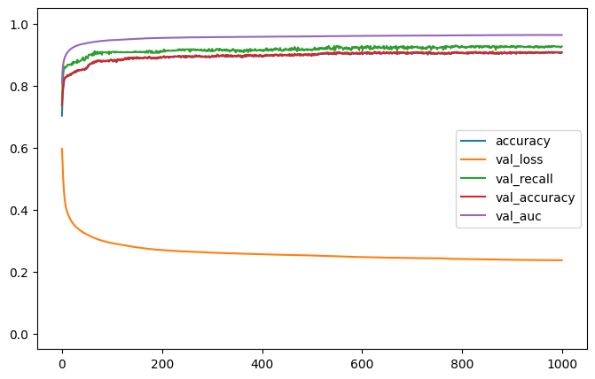

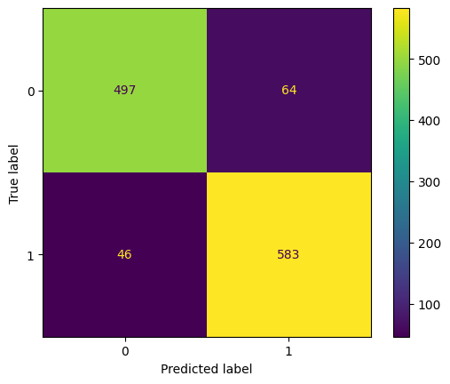

```python
evaluate_model(model, history, X, y)
```

```python
model = Sequential()
model.add(Dense(12, input_dim=X.shape[1], activation='relu'))
model.add(Dense(1, activation='sigmoid'))
print(model.summary())
history = train_model(model, X, y, X, y)
```

```
Model: "sequential_4"
_________________________________________________________________
 Layer (type)                Output Shape              Param #
=================================================================
 dense_7 (Dense)             (None, 12)                204

 dense_8 (Dense)             (None, 1)                 13

=================================================================
Total params: 217 (868.00 Byte)
Trainable params: 217 (868.00 Byte)
Non-trainable params: 0 (0.00 Byte)
_________________________________________________________________
None
```

```
Accuracy:  0.94
Specificity:  0.93
Recall:  0.96
F1 Score: 0.95
```

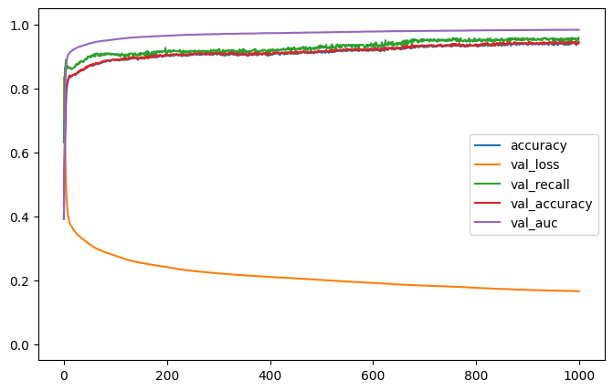

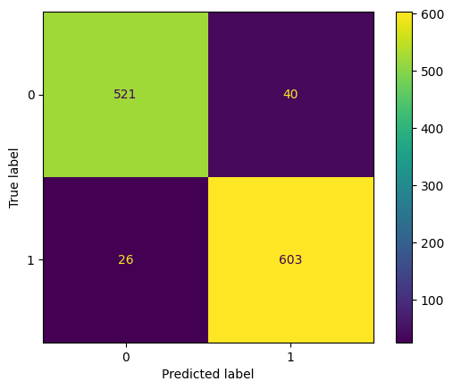

```python
evaluate_model(model, history, X, y)
```

```python
model = Sequential()
model.add(Dense(16, input_dim=X.shape[1], activation='relu'))
model.add(Dense(1, activation='sigmoid'))
print(model.summary())
history = train_model(model, X, y, X, y)
```

```
Model: "sequential_5"
_________________________________________________________________
 Layer (type)                Output Shape              Param #
=================================================================
 dense_9 (Dense)             (None, 16)                272

 dense_10 (Dense)            (None, 1)                 17

=================================================================
Total params: 289 (1.13 KB)
Trainable params: 289 (1.13 KB)
Non-trainable params: 0 (0.00 Byte)
_________________________________________________________________
None
```

```
Accuracy:  0.97
Specificity:  0.97
Recall:  0.98
F1 Score: 0.97
```

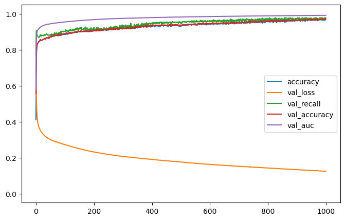

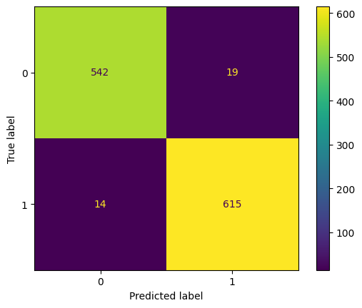

```python
evaluate_model(model, history, X, y)
```

```python
model = Sequential()
model.add(Dense(16, input_dim=X.shape[1], activation='relu'))
model.add(Dense(2, activation='relu'))
model.add(Dense(1, activation='sigmoid'))
print(model.summary())
history = train_model(model, X, y, X, y)
```

```
Model: "sequential_6"
_________________________________________________________________
 Layer (type)                Output Shape              Param #
=================================================================
 dense_11 (Dense)            (None, 16)                272

 dense_12 (Dense)            (None, 2)                 34

 dense_13 (Dense)            (None, 1)                 3

=================================================================
Total params: 309 (1.21 KB)
Trainable params: 309 (1.21 KB)
Non-trainable params: 0 (0.00 Byte)
_________________________________________________________________
None
```

```
Accuracy:  0.98
Specificity:  0.97
Recall:  0.99
F1 Score: 0.98
```

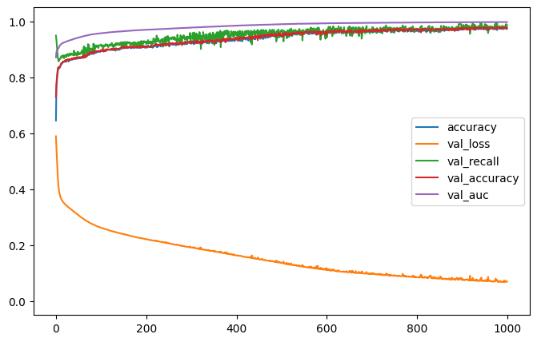

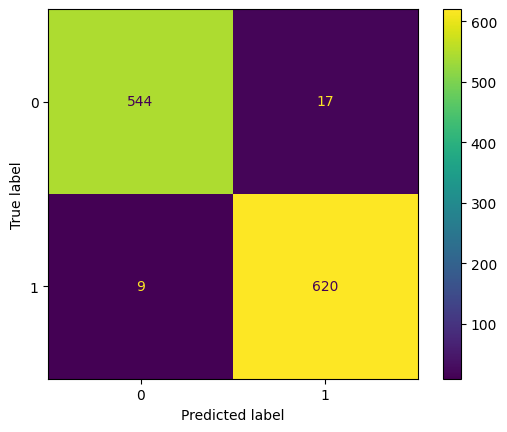

```python
evaluate_model(model, history, X, y)
```

```python
model = Sequential()
model.add(Dense(16, input_dim=X.shape[1], activation='relu'))
model.add(Dense(4, activation='relu'))
model.add(Dense(1, activation='sigmoid'))
print(model.summary())
history = train_model(model, X, y, X, y)
```

```
Model: "sequential_7"
_________________________________________________________________
 Layer (type)                Output Shape              Param #
=================================================================
 dense_14 (Dense)            (None, 16)                272

 dense_15 (Dense)            (None, 4)                 68

 dense_16 (Dense)            (None, 1)                 5

=================================================================
Total params: 345 (1.35 KB)
Trainable params: 345 (1.35 KB)
Non-trainable params: 0 (0.00 Byte)
_________________________________________________________________
None
```

```
Accuracy:  1.0
Specificity:  0.99
Recall:  1.0
F1 Score: 1.0
```

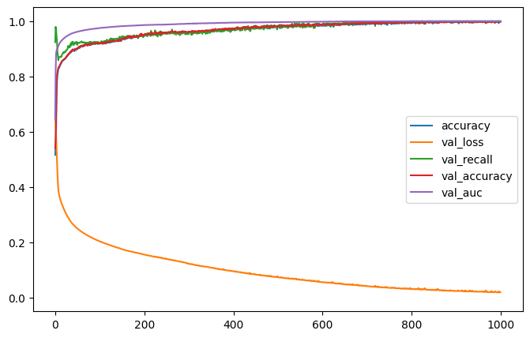

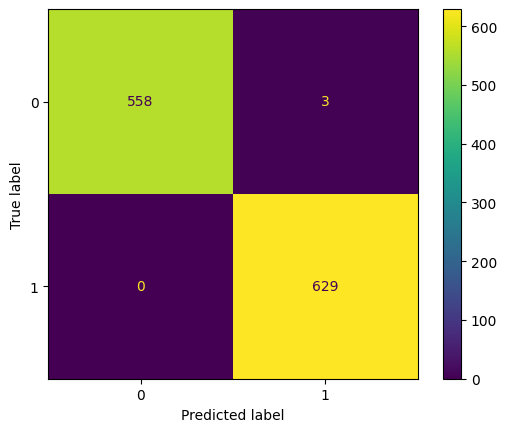

```python
evaluate_model(model, history, X, y)
```

```python
model = Sequential()
model.add(Dense(16, input_dim=X.shape[1], activation='relu'))
model.add(Dense(8, activation='relu'))
model.add(Dense(1, activation='sigmoid'))
print(model.summary())
history = train_model(model, X, y, X, y)
```

```
Model: "sequential_8"
_________________________________________________________________
 Layer (type)                Output Shape              Param #
=================================================================
 dense_17 (Dense)            (None, 16)                272

 dense_18 (Dense)            (None, 8)                 136

 dense_19 (Dense)            (None, 1)                 9

=================================================================
Total params: 417 (1.63 KB)
Trainable params: 417 (1.63 KB)
Non-trainable params: 0 (0.00 Byte)
_________________________________________________________________
None
```

```
Accuracy:  1.0
Specificity:  1.0
Recall:  1.0
F1 Score: 1.0
```

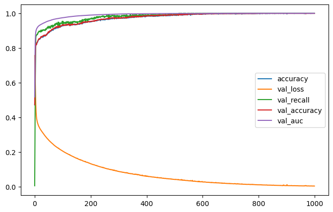

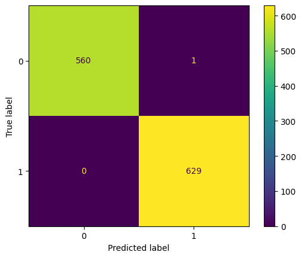

```python
evaluate_model(model, history, X, y)
```

```python
model = Sequential()
model.add(Dense(16, input_dim=X.shape[1], activation='relu'))
model.add(Dense(16, activation='relu'))
model.add(Dense(1, activation='sigmoid'))
print(model.summary())
history = train_model(model, X, y, X, y)
```

```
Model: "sequential_9"
_________________________________________________________________
 Layer (type)                Output Shape              Param #
=================================================================
 dense_20 (Dense)            (None, 16)                272

 dense_21 (Dense)            (None, 16)                272

 dense_22 (Dense)            (None, 1)                 17

=================================================================
Total params: 561 (2.19 KB)
Trainable params: 561 (2.19 KB)
Non-trainable params: 0 (0.00 Byte)
_________________________________________________________________
None
```

```
Accuracy:  1.0
Specificity:  1.0
Recall:  1.0
F1 Score: 1.0
```

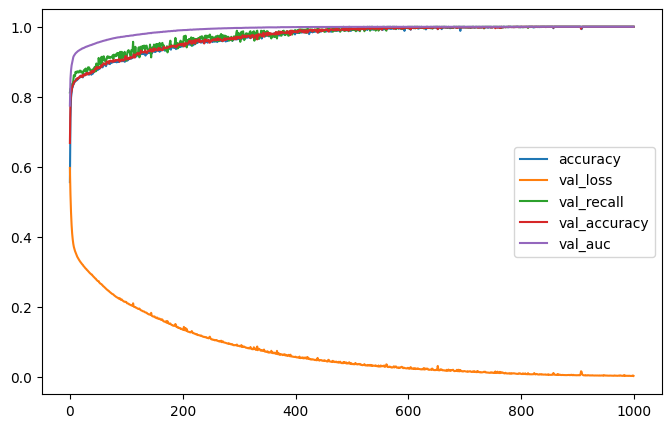

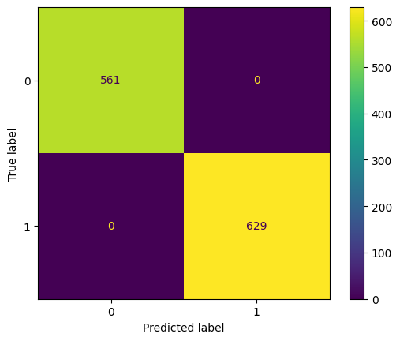

```python
evaluate_model(model, history, X, y)
```

```python
model = Sequential()
model.add(Dense(16, input_dim=X.shape[1], activation='relu'))
model.add(Dense(16, activation='relu'))
model.add(Dense(16, activation='relu'))
model.add(Dense(1, activation='sigmoid'))
print(model.summary())
history = train_model(model, X, y, X, y)
```

```
Model: "sequential_10"
_________________________________________________________________
 Layer (type)                Output Shape              Param #
=================================================================
 dense_23 (Dense)            (None, 16)                272

 dense_24 (Dense)            (None, 16)                272

 dense_25 (Dense)            (None, 16)                272

 dense_26 (Dense)            (None, 1)                 17

=================================================================
Total params: 833 (3.25 KB)
Trainable params: 833 (3.25 KB)
Non-trainable params: 0 (0.00 Byte)
_________________________________________________________________
None
Epoch 710: early stopping
```

```
Accuracy:  1.0
Specificity:  1.0
Recall:  1.0
F1 Score: 1.0
```

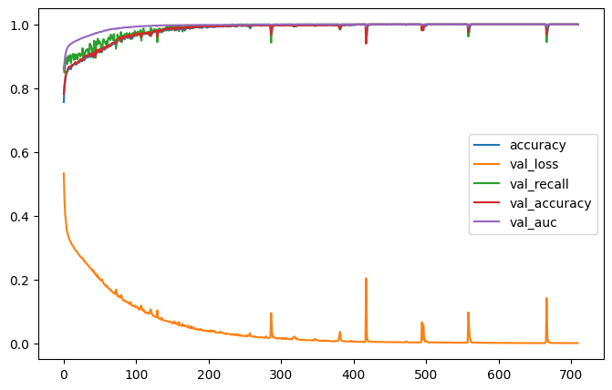

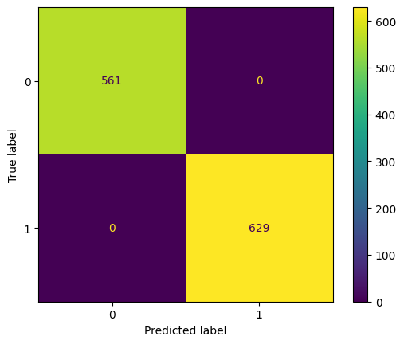

```python
evaluate_model(model, history, X, y)
```

## Phase 3: Model Selection and Evaluation

The main goal in this phase is to obtain highest possible accuracy on the validation set after splitting your data into training set and validation set.

- Please shuffle your rows before splitting.
- As your baseline model, i.e., the model with minimum accuracy, you can test the accuracy on the validation set using a ‘logistic regression’ model.
- Gradually grow your model into a multi-layered model and investigate if larger models deliver higher accuracy on the validation set.
  - As you explore various network architectures, please note the accuracies of these models to include in your report.
  - You can summarize your findings in the form of a table and the table should contain the accuracy and loss on the training set and the validation set (see below).
  - You can also include other parameters such as number of epochs, number of neurons, total number of parameters, etc.
- Remember to select one model as your best performing model, i.e., the model that delivers highest accuracy on the validation set.
- Your report should also include learning curves of your experiments.
- You should also evaluate your models using other metrics besides precision; for example recall, precision, and F1 score.
- Please note that your submission for this phase is ineligible for points if you do not use “model checkpointing” in your code.
- You are discouraged to use external library methods such as “from sklearn.model_selection import train_test_split”.

[FOR GRADUATE STUDENTS ONLY]

- discuss what architecture (how big) you do need to overfit when you have output as additional input feature,
- code a function that represents your model.
  - Once you have finished coding your model, please build your own function/method that serves as a prediction model.
  - Afterwards, please verify that predictions you obtain are same as the one you obtained using your trained model.

```python
# shuffle rows
np.random.seed(2112)
df = df.sample(frac=1)
```

```python
df.shape
```

```
(1190, 17)
```

```python
# split our data
df_train = df.iloc[:990, :]
df_test = df.iloc[990:, :]
```

```python
X_train = df_train.drop(axis=1, labels='target')
y_train = df_train['target']
X_test = df_test.drop(axis=1, labels='target')
y_test = df_test['target']
```

```python
# Create a transformer from the training data and use it to res-scale the training and test data
```

```python
transform_dict = {}

for column in numeric_cols:
    transform_dict[column] = X_train[column].mean(), X_train[column].std()
```

```python
transform_dict
```

```
{'age': (53.58585858585859, 9.37048924959344),
 'resting_bp_s': (132.07676767676767, 18.642888615007955),
 'cholesterol': (209.33030303030304, 101.84296180130552),
 'max_heart_rate': (139.65454545454546, 25.558629333612505),
 'oldpeak': (0.9293939393939393, 1.0990641466017517)}
```

```python
def data_norms_2(data, mean, std):
    return (data - mean)/std
```

```python
for column in numeric_cols:
    X_train[column] = data_norms_2(X_train[column],
                                            transform_dict[column][0],
                                            transform_dict[column][1])
```

```python
for column in numeric_cols:
    X_test[column] = data_norms_2(X_test[column],
                                            transform_dict[column][0],
                                            transform_dict[column][1])
```

```python
# Verify
X_train[numeric_cols].describe().transpose()
```

|  | count | mean | std | min | 25% | 50% | 75% | max |
| --- | --- | --- | --- | --- | --- | --- | --- | --- |
| age | 990.0 | -2.727336e-16 | 1.0 | -2.730472 | -0.702830 | 0.044196 | 0.684504 | 2.498711 |
| resting_bp_s | 990.0 | 1.830186e-16 | 1.0 | -7.084566 | -0.647795 | -0.111397 | 0.425000 | 3.643386 |
| cholesterol | 990.0 | -1.094523e-16 | 1.0 | -2.055422 | -0.209443 | 0.198047 | 0.585899 | 3.865458 |
| max_heart_rate | 990.0 | -6.728624e-17 | 1.0 | -3.116542 | -0.729873 | 0.013516 | 0.796031 | 2.439311 |
| oldpeak | 990.0 | 1.040694e-16 | 1.0 | -3.211272 | -0.845623 | -0.299704 | 0.587414 | 4.795540 |

### Logistic Regression

```python
formula = "target ~"
for col in X_train.columns:
    formula += " + "
    formula += col
logit = smf.logit(formula, data=pd.concat([X_train, y_train], axis=1)).fit()
```

```python
print(logit.summary())
```

```
                           Logit Regression Results
==============================================================================
Dep. Variable:                 target   No. Observations:                  990
Model:                          Logit   Df Residuals:                      973
Method:                           MLE   Df Model:                           16
Date:                Sun, 28 Apr 2024   Pseudo R-squ.:                  0.5117
Time:                        18:23:10   Log-Likelihood:                -334.29
converged:                      False   LL-Null:                       -684.63
Covariance Type:            nonrobust   LLR p-value:                9.243e-139
=======================================================================================
                          coef    std err          z      P>|z|      [0.025      0.975]
---------------------------------------------------------------------------------------
Intercept              25.7491   1.65e+06   1.56e-05      1.000   -3.23e+06    3.23e+06
age                     0.2414      0.116      2.076      0.038       0.014       0.469
sex                     1.7558      0.262      6.707      0.000       1.243       2.269
resting_bp_s            0.0790      0.103      0.768      0.442      -0.123       0.281
cholesterol            -0.3818      0.113     -3.383      0.001      -0.603      -0.161
fasting_blood_sugar     0.9207      0.262      3.510      0.000       0.407       1.435
max_heart_rate         -0.0908      0.124     -0.734      0.463      -0.333       0.152
exercise_angina         0.8499      0.228      3.732      0.000       0.404       1.296
oldpeak                 0.5644      0.121      4.675      0.000       0.328       0.801
chest_pain_type_2       0.2836      0.463      0.612      0.541      -0.625       1.192
chest_pain_type_3       0.1552      0.412      0.377      0.707      -0.653       0.963
chest_pain_type_4       2.1239      0.408      5.204      0.000       1.324       2.924
ecg_1                  -0.3026      0.307     -0.985      0.325      -0.905       0.299
ecg_2                   0.0678      0.235      0.288      0.773      -0.393       0.529
ST_slope_1            -29.7173   1.65e+06  -1.81e-05      1.000   -3.23e+06    3.23e+06
ST_slope_2            -27.5546   1.65e+06  -1.67e-05      1.000   -3.23e+06    3.23e+06
ST_slope_3            -29.0755   1.65e+06  -1.77e-05      1.000   -3.23e+06    3.23e+06
=======================================================================================
```

```python
# Note the coefficients on the ST_slope variables. There is likely an issue of over-identification.
# We will drop the variable with the lowest correlation to our target, "ST_slope_3", and see what happens.
formula = "target ~"
for col in X_train.drop(labels=["ST_slope_3"], axis=1).columns:
    formula += " + "
    formula += col
logit = smf.logit(formula, data=pd.concat([X_train.drop(labels=["ST_slope_3"], axis=1), y_train], axis=1)).fit()
```

```
Optimization terminated successfully.
         Current function value: 0.338564
         Iterations 7
```

```python
print(logit.summary())
```

```
                           Logit Regression Results
==============================================================================
Dep. Variable:                 target   No. Observations:                  990
Model:                          Logit   Df Residuals:                      974
Method:                           MLE   Df Model:                           15
Date:                Sun, 28 Apr 2024   Pseudo R-squ.:                  0.5104
Time:                        18:23:11   Log-Likelihood:                -335.18
converged:                       True   LL-Null:                       -684.63
Covariance Type:            nonrobust   LLR p-value:                3.182e-139
=======================================================================================
                          coef    std err          z      P>|z|      [0.025      0.975]
---------------------------------------------------------------------------------------
Intercept              -3.2516      0.597     -5.448      0.000      -4.421      -2.082
age                     0.2520      0.116      2.173      0.030       0.025       0.479
sex                     1.7616      0.262      6.736      0.000       1.249       2.274
resting_bp_s            0.0849      0.103      0.826      0.409      -0.116       0.286
cholesterol            -0.3761      0.113     -3.332      0.001      -0.597      -0.155
fasting_blood_sugar     0.9370      0.262      3.573      0.000       0.423       1.451
max_heart_rate         -0.0901      0.124     -0.728      0.467      -0.333       0.153
exercise_angina         0.8410      0.228      3.693      0.000       0.395       1.287
oldpeak                 0.5474      0.120      4.575      0.000       0.313       0.782
chest_pain_type_2       0.2901      0.463      0.626      0.531      -0.618       1.198
chest_pain_type_3       0.1853      0.411      0.451      0.652      -0.621       0.991
chest_pain_type_4       2.1347      0.408      5.228      0.000       1.334       2.935
ecg_1                  -0.3231      0.307     -1.053      0.292      -0.924       0.278
ecg_2                   0.0512      0.235      0.218      0.828      -0.409       0.512
ST_slope_1             -0.7342      0.424     -1.730      0.084      -1.566       0.098
ST_slope_2              1.4361      0.403      3.566      0.000       0.647       2.225
=======================================================================================
```

```python
# Drop the extra feature
X.drop(labels=["ST_slope_3"], axis=1, inplace=True)
X_train.drop(labels=["ST_slope_3"], axis=1, inplace=True)
X_test.drop(labels=["ST_slope_3"], axis=1, inplace=True)
```

```
Accuracy:  0.81
Specificity:  0.78
Recall:  0.85
F1 Score: 0.83
```

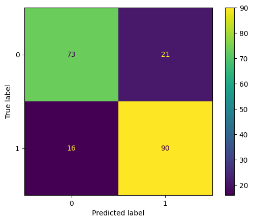

```python
y_pred_logit = logit.predict(X_test)
y_pred_logit = (y_pred_logit >= 0.5)*1
scores(y_test, y_pred_logit)
conf_matrix = confusion_matrix(y_test, y_pred=y_pred_logit)
vis = ConfusionMatrixDisplay(confusion_matrix=conf_matrix)
vis.plot()
plt.show()
```